tyoc213 blog

# Reconociendo dígitos en fastai2

Como reconocer los dígitos de la competición https://www.kaggle.com/c/digit-recognizer

May 26, 2020 • tyoc213 • 14 min read

fastai2

- Instalar fastai2
  - Registrandose en kaggle
  - Importar fastai2
  - show batch
  - Cargar un modelo y entrenarlo
  - Ahora podemos entrenarlo con fine_tune
  - Fine tunning
  - Exportar a producción

# Instalar fastai2

http://dev.fast.ai/#Installing yo prefiero instalarlo como dice ahí en su propio entorno de conda.

```
git clone https://github.com/fastai/fastai2
cd fastai2
pip install -e ".[dev]"
```

para que CUDA este disponible `python -c 'import torch; print(torch.cuda.is_available())'` si no lo esta checa que este instalado con `nvidia-smi`, si esta instalado puede que no se haya instalado la versión correcta de pytorch y los drivers instalados ve como hacerlo en https://pytorch.org/get-started/locally/

## Registrandose en kaggle

1. Registrarse como usuario en kaggle
2. hacer `pip install kaggle`
3. Obtener tu clave privada de usuario y guardarla en la ruta default
4. Entrar en https://www.kaggle.com/c/digit-recognizer y dar click en aceptar reglas para poder usar la aplicación de kaggle.
5. Bajar los archivos con `kaggle competitions download -c digit-recognizer` y descomprimirlos en su propia carpeta

## Importar fastai2

Importamos el modulo vision de fastai2

```python
from fastai2.vision.all import *
```

Vamos a definir algunas variables para poder ponerle nombre a nuestros archivos a enviar y guardar el nombre del modelo que usamos.

```python
VERSION = 4
MODELO=resnet34
NOMBRE_MODELO="resnet34"
BASE_FILE = f"base-{NOMBRE_MODELO}_v{VERSION}"
SUBMIT_FILE = f"submit-{NOMBRE_MODELO}_v{VERSION}"

FINE_FILE = f"base-{NOMBRE_MODELO}-fine_v{VERSION}"
SUBMIT_FINE_FILE = f"submit-{NOMBRE_MODELO}-fine_v{VERSION}"
```

Fastai2 trabaja muy bien con data loaders, estos necesitan que exista algun archivo en disco, lo cual puede ayudar para datasets grandes, pero tal vez no mucho a su lectura recurrente. Sólo necesitamos preprocesar esto la primer vez, por lo mismo usamos esos `if`s para extraerlos si es necesario desde cada row del `csv` hacia la imagen en disco.

```python
import string
# in the same folder I have downloaded with: kaggle competitions download -c digit-recognizer
path = untar_data("file://digit-recognizer.zip", dest=".")
#print(path)
#print(path.ls())

from PIL import Image
from matplotlib import cm

import pandas as pd

path = Path("digit-recognizer")
df = pd.read_csv(path/"train.csv", header='infer')
df.head()
```

|  | label | pixel0 | pixel1 | pixel2 | pixel3 | pixel4 | pixel5 | pixel6 | pixel7 | pixel8 | ... | pixel774 | pixel775 | pixel776 | pixel777 | pixel778 | pixel779 | pixel780 | pixel781 | pixel782 | pixel783 |
| --- | --- | --- | --- | --- | --- | --- | --- | --- | --- | --- | --- | --- | --- | --- | --- | --- | --- | --- | --- | --- | --- |
| 0 | 1 | 0 | 0 | 0 | 0 | 0 | 0 | 0 | 0 | 0 | ... | 0 | 0 | 0 | 0 | 0 | 0 | 0 | 0 | 0 | 0 |
| 1 | 0 | 0 | 0 | 0 | 0 | 0 | 0 | 0 | 0 | 0 | ... | 0 | 0 | 0 | 0 | 0 | 0 | 0 | 0 | 0 | 0 |
| 2 | 1 | 0 | 0 | 0 | 0 | 0 | 0 | 0 | 0 | 0 | ... | 0 | 0 | 0 | 0 | 0 | 0 | 0 | 0 | 0 | 0 |
| 3 | 4 | 0 | 0 | 0 | 0 | 0 | 0 | 0 | 0 | 0 | ... | 0 | 0 | 0 | 0 | 0 | 0 | 0 | 0 | 0 | 0 |
| 4 | 0 | 0 | 0 | 0 | 0 | 0 | 0 | 0 | 0 | 0 | ... | 0 | 0 | 0 | 0 | 0 | 0 | 0 | 0 | 0 | 0 |

5 rows × 785 columns

```python
%%time
def get_image(csv_row):
    img = csv_row.reshape(28,28)
    x = cm.gist_earth(img)*255
    return Image.fromarray(np.uint8(x))

def explode_train():
    df = pd.read_csv(path/'train.csv', header='infer')
    imagenes = df.iloc[:,1:].apply(lambda x: x.values, axis=1).values
    labels = df.iloc[:,:1].apply(lambda x: x.values[0], axis=1)
    p = Path(path)/'train'
    p.mkdir(parents=True, exist_ok=True)

    for idx, l in enumerate(labels):
        im = get_image(imagenes[idx])
        image_name = (str(l)+"_"+'train'+'_'+''.join(random.choice(string.ascii_lowercase) for i in range(8))) + ".png"
        im.save(p/image_name)

def explode_test():
    df = pd.read_csv(path/'test.csv', header='infer')
    imagenes = df.iloc[:,:].apply(lambda x: x.values, axis=1).values
    p = Path(path)/'test'
    p.mkdir(parents=True, exist_ok=True)
    for idx, l in enumerate(imagenes):
        im = get_image(imagenes[idx])
        im.save(p / f"{idx}.png")
if not (path/'train').exists():
    explode_train()
if not (path/'test').exists():
    explode_test()
```

```
CPU times: user 106 µs, sys: 13 µs, total: 119 µs
Wall time: 81.1 µs
```

Para leer todas las imagenes generadas, lo haciemos por medio de un `DataBlock` el cual es un `blueprint` de donde, como y que vamos a hacer con esas imagenes para obtener finalmente las imagenes en `batches` o grupos de imagenes (de 64 en 64 por default) y la carga de las imagenes como tal se hace por medio de `data_loader = data_block.dataloaders(path)` el cual en este caso también aprende el "vocabulario" a aprender ya que se ha especificado que el segundo bloque es un bloque de categorias a diferencia del primero que es de Imagenes.

`get_my_labels` obtiene a partir de el archivo de imagen leído el nombre y regresa el dígito al que pertenece del vocabulario.

```python
%%time
def get_my_labels(fname):
    return int(fname.name[0])

dblock = DataBlock(
    splitter  = RandomSplitter(),
    item_tfms = Resize(224),
    blocks    = (ImageBlock, CategoryBlock),
    get_items = get_image_files,
    get_y     = get_my_labels
    )

dls = dblock.dataloaders("digit-recognizer/train")
dls.vocab
```

```
CPU times: user 4.12 s, sys: 549 ms, total: 4.67 s
Wall time: 4.81 s
```

```
(#10) [0,1,2,3,4,5,6,7,8,9]
```

## show batch

Podemos ver que realmente este encontrando las imagenes mostrando un batch de imagenes.

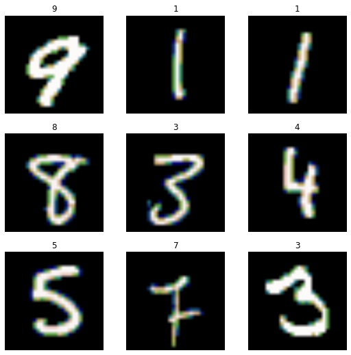

```python
dls.show_batch()
```

## Cargar un modelo y entrenarlo

En fastai2 podemos cargar un modelo ya entrenado y reusarlo para ajustarlo a la tarea que queremos llevar a cabo.

```python
learn = cnn_learner(dls, MODELO, metrics=error_rate)
```

Nuestro modelo en este momento ya tiene una estructura la cual se puede sumarizar así

```python
learn.summary()
```

```
Sequential (Input shape: ['64 x 3 x 224 x 224'])
================================================================
Layer (type)         Output Shape         Param #    Trainable
================================================================
Conv2d               64 x 64 x 112 x 112  9,408      False
________________________________________________________________
BatchNorm2d          64 x 64 x 112 x 112  128        True
________________________________________________________________
ReLU                 64 x 64 x 112 x 112  0          False
________________________________________________________________
MaxPool2d            64 x 64 x 56 x 56    0          False
________________________________________________________________
Conv2d               64 x 64 x 56 x 56    36,864     False
________________________________________________________________
BatchNorm2d          64 x 64 x 56 x 56    128        True
________________________________________________________________
ReLU                 64 x 64 x 56 x 56    0          False
________________________________________________________________
Conv2d               64 x 64 x 56 x 56    36,864     False
________________________________________________________________
BatchNorm2d          64 x 64 x 56 x 56    128        True
________________________________________________________________
Conv2d               64 x 64 x 56 x 56    36,864     False
________________________________________________________________
BatchNorm2d          64 x 64 x 56 x 56    128        True
________________________________________________________________
ReLU                 64 x 64 x 56 x 56    0          False
________________________________________________________________
Conv2d               64 x 64 x 56 x 56    36,864     False
________________________________________________________________
BatchNorm2d          64 x 64 x 56 x 56    128        True
________________________________________________________________
Conv2d               64 x 64 x 56 x 56    36,864     False
________________________________________________________________
BatchNorm2d          64 x 64 x 56 x 56    128        True
________________________________________________________________
ReLU                 64 x 64 x 56 x 56    0          False
________________________________________________________________
Conv2d               64 x 64 x 56 x 56    36,864     False
________________________________________________________________
```

[output cut: 163 more lines]

```
________________________________________________________________

Total params: 21,817,152
Total trainable params: 549,504
Total non-trainable params: 21,267,648

Optimizer used: <function Adam at 0x7fb52353ab00>
Loss function: FlattenedLoss of CrossEntropyLoss()

Model frozen up to parameter group number 2

Callbacks:
  - TrainEvalCallback
  - Recorder
  - ProgressCallback
```

Podemos ver las predicciones actuales antes de reajustar los parametros de la red. En rojo se muestran los errores en verde los que estan bien. Los aciertos más bien son aleatorios.

Los resultados como se espera no pueden reconocer los patrones ya que esta inicializada para otro tipo de tarea.

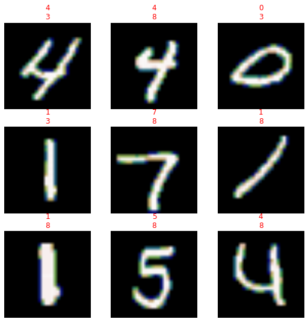

```python
learn.show_results()
```

## Ahora podemos entrenarlo con fine_tune

El método fit sirve para ejecutar una serie de pasadas sobre los datos de entrenamiento.

```python
%%time
learn.fine_tune(1)
```

| epoch | train_loss | valid_loss | error_rate | time |
| --- | --- | --- | --- | --- |
| 0 | 0.227946 | 0.135213 | 0.040000 | 01:16 |

| epoch | train_loss | valid_loss | error_rate | time |
| --- | --- | --- | --- | --- |
| 0 | 0.035625 | 0.025032 | 0.007024 | 01:43 |

```
CPU times: user 2min 15s, sys: 26.2 s, total: 2min 42s
Wall time: 3min
```

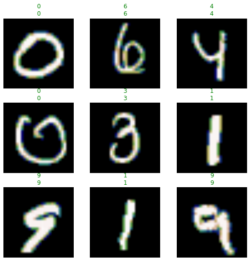

```python
learn.show_results()
```

Nuestro modelo en este momento ya puede asertar con más confianza el dígito que se le esta pasando

```python
learn.predict(Path("digit-recognizer")/'test'/"1111.png")
```

```
('2',
 tensor(2),
 tensor([8.4126e-10, 8.9289e-08, 1.0000e+00, 7.2959e-07, 2.4069e-09, 2.0494e-08,
         2.9449e-09, 1.0405e-07, 2.0946e-07, 1.2205e-10]))
```

Si volvemos a checar los resultados podemos ver que ciertamente ya puede reconocer los patrones.

Veamos cuales son las imagenes que más costaron reconocer.

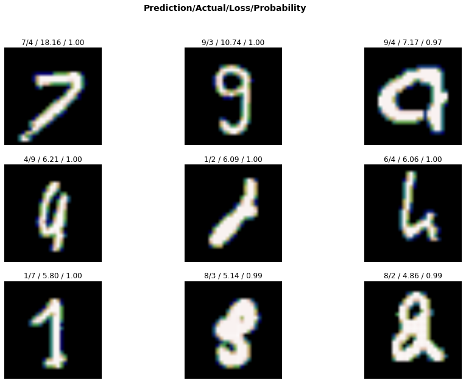

```python
interp = Interpretation.from_learner(learn)
interp.plot_top_losses(9, figsize=(15,10))
```

Para guardar los resultados obtenidos y mandarlos a kaggle, basta con hacer lo siguiente

```python
def predict_test(the_learner, file_name):
    p = path/'test'
    print(f"predicting {len(p.ls())} in {p}")
    l = []
    for idx, img in enumerate(p.ls()):
        fname = p/f"{idx}.png"
        pred = the_learner.predict(fname)
        # la predicción contiene todo el resultado, la predicción esta en el elemento 0
        l.append( [idx+1, int(pred[0])] )
        if idx % 2800 == 0:
            print(f"{[idx, pred[0]]}...")
    df = pd.DataFrame(l)
    h = ["ImageId","label"]
    df.to_csv(f"{file_name}.csv", header=h, index=False) if True else print("** skipped save **")
    print("done!")
```

Removemos el callback del loader

```python
%%time
learn.remove_cb(learn.cbs[2])
predict_test(learn, BASE_FILE)
```

```
predicting 28000 in digit-recognizer/test
[0, '2']...
[2800, '4']...
[5600, '8']...
[8400, '5']...
[11200, '4']...
[14000, '3']...
[16800, '1']...
[19600, '5']...
[22400, '9']...
[25200, '3']...
done!
CPU times: user 53min 39s, sys: 1h 36min 21s, total: 2h 30min
Wall time: 2h 49min 33s
```

El `Learner` que actualmente se encuentra en `learn` es muy bueno para quedar cerca de los primeros mil competidores, lo que tenemos que hacer ahora es mejorarlo poco a poco.

Pero antes de esto vamos a salvarlo de 2 formas:

- exportandolo el cual requiere que despues se vuelva a cargar y crear otro cnn
- salvar y cargar de manera directa

Guardamos el modelo actual para poder cargarlo despues via `load`.

```python
learn.save(BASE_FILE) if True else print("No se a guardado el archivo")
```

## Fine tunning

Ahora se puede cargar desde donde se quedo el paso guardado por save anterior, pero debe de contener datos a los cuales referirse, por eso se carga a travez de un modelo instanciado igual que antes, sólo que este ya esta "entrenado" a la tarea actual.

```python
l2 = cnn_learner(dls, MODELO, metrics=error_rate)
```

Una vez instanciado igual que el modelo que guardamos, se puede cargar el mismo desde el archivo que se guardo con `learn.save`

```python
l2.load(BASE_FILE)
```

```
<fastai2.learner.Learner at 0x7fb5202f10d0>
```

Buscamos un buen learning rate

```
SuggestedLRs(lr_min=0.00043651582673192023, lr_steep=6.309573450380412e-07)
```

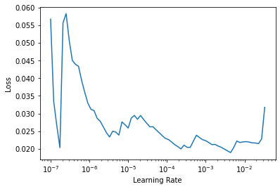

```python
l2.lr_find()
```

```python
%%time
l2.unfreeze()
l2.fine_tune(8, 1e-2)
```

| epoch | train_loss | valid_loss | error_rate | time |
| --- | --- | --- | --- | --- |
| 0 | 0.080212 | 0.057889 | 0.010238 | 01:10 |

| epoch | train_loss | valid_loss | error_rate | time |
| --- | --- | --- | --- | --- |
| 0 | 0.074369 | 0.067521 | 0.013690 | 01:36 |
| 1 | 0.082539 | 0.081573 | 0.018690 | 01:36 |
| 2 | 0.058147 | 0.052700 | 0.015238 | 01:35 |
| 3 | 0.042055 | 0.044290 | 0.009048 | 01:34 |
| 4 | 0.029418 | 0.040308 | 0.009048 | 01:33 |
| 5 | 0.008509 | 0.022320 | 0.004286 | 01:34 |
| 6 | 0.003744 | 0.021935 | 0.004286 | 01:36 |
| 7 | 0.000918 | 0.023328 | 0.004524 | 01:35 |

```
CPU times: user 10min 46s, sys: 2min 52s, total: 13min 38s
Wall time: 13min 53s
```

Guardamos el nuevo modelo ajustado

```python
l2.save(FINE_FILE)
```

Y lo usamos para predecir eliminando también el callback del progress bar

```python
l2.cbs, l2.cbs[2]
```

```
((#3) [TrainEvalCallback,Recorder,ProgressCallback], ProgressCallback)
```

```python
%%time
l2.remove_cb(l2.cbs[2])
predict_test(l2, FINE_FILE)
```

```
predicting 28000 in digit-recognizer/test
[0, '2']...
[2800, '4']...
[5600, '8']...
[8400, '5']...
[11200, '4']...
[14000, '3']...
[16800, '1']...
[19600, '5']...
[22400, '9']...
[25200, '3']...
done!
CPU times: user 39min 42s, sys: 1h 35min 30s, total: 2h 15min 13s
Wall time: 2h 36min 45s
```

```python
l2.validate()
```

```
(#2) [0.023327725008130074,0.0045238095335662365]
```

## Exportar a producción

Si no queremos seguir reentrenando nuestro trabajo, podemos sólo exportar el modelo para que se use en predicciones al cargarlo.

```python
learn.export(BASE_FILE) if False else print("no se ha exportado")
```

```
no se ha exportado
```

```python
l2.export(FINE_FILE) if False else print("no se ha exportado nada")
```

```
no se ha exportado nada
```